# Basic multivariate data analysis

Exclusion

28/09/2021

This chapter uses dataset to go through methods to visualise and analyse high dimensional data in 2-D view.

Load some useful packages first.

As usual, scatterplot matrix can provide us with a good initial understanding of the variable, but it's not effective for a big picture.

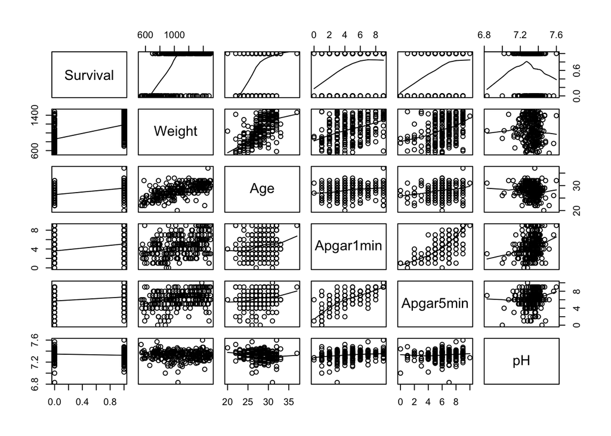

```r
pairs(baby,panel=function(x,y){points(x,y);lines(lowess(x,y))})
```

We now try symbol plots to display multiple variables in 2 dimensions. This plot can present two covariates, use length and width to represent another 2 covariates and use the filled symbol to allow 0/1 colour coding.

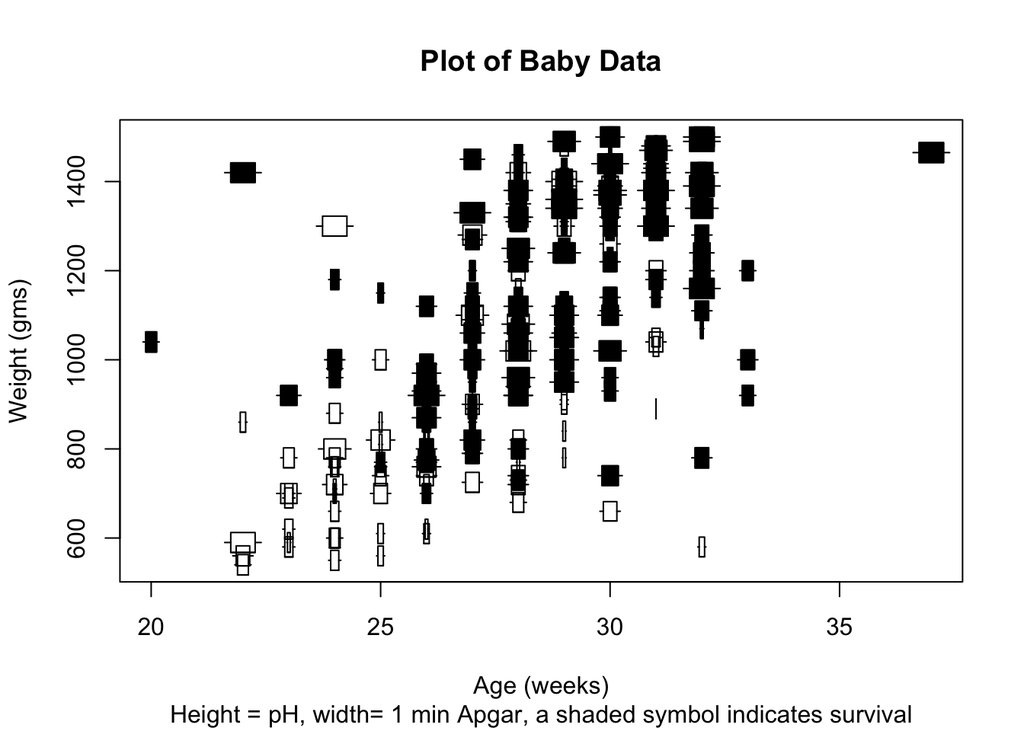

```r
plot(baby[,3],baby[,2],type="n",
     xlab="Age (weeks)",
     ylab="Weight (gms)",
     main="Plot of Baby Data",
     sub="Height = pH, width= 1 min Apgar, a shaded symbol indicates survival")
surv = (baby[,1] == 1)
symbols(baby[,3],baby[,2],thermometers=cbind(baby[,4],baby[,6],surv), add=T,inches = 1/6)
```

We may also use circles and square. However, this leads to ambiguity on the size representation as we often analyse the circle area instead of radius, which exaggerates the size difference.

In general, we want the dimension of symbols to be the same as the dimension of the set of variables to represent. So to represent 2 variables, we need rectangles or stars.

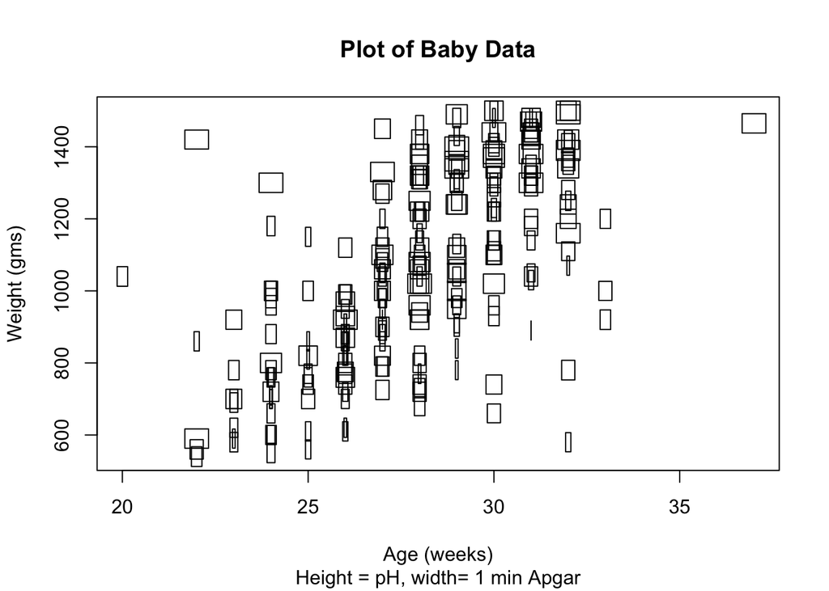

```r
plot(baby[,3],baby[,2],type="n", xlab="Age (weeks)",ylab="Weight (gms)",
     main="Plot of Baby Data", sub="Height = pH, width= 1 min Apgar")
## rectangles: first argument is width, then height
symbols(baby[,3],baby[,2],rectangles = cbind(baby[,4],baby[,6]),add=T,inches=1/5)
```

We can see a trend from lower 1min Apgar to higher (wider rectangles) from lower left to upper right.

Also, given we have a categorical variable survival (0/1), we can also colour code each point to allow contrast - this gives 3 variables on one plot and such visualisation can give an initial sense of classification boundary

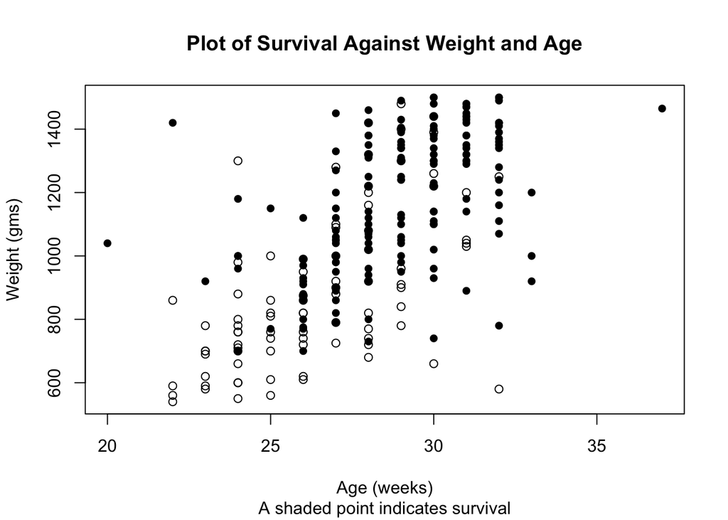

```r
plot(baby[,3],baby[,2],type="n",
     xlab="Age (weeks)",
     ylab="Weight (gms)",
     main="Plot of Survival Against Weight and Age",
     sub="A shaded point indicates survival")
surv = (baby[,1] == 1)
points(baby[!surv,3],baby[!surv,2],pch=1)
points(baby[surv,3],baby[surv,2],pch=16)
```

However, when the symbols contain more information, it's better to assign coarse grouping or discretise the covariates into low/high or high/medium/low. This gives a "co-plot" that can see how the relationship changes as a third variable moves from low to high.

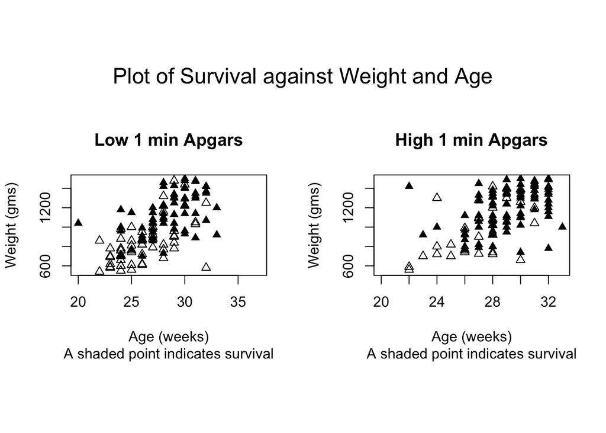

```r
### divide the Apgars into 2 parts, low and high
ind = (baby[,4] <= 4)
par(mfrow=c(1,2),oma=c(4,0,6,0))
### First plot the symbol plot for the low apgars
plot(baby[,3],baby[,2],type="n",
     xlab="Age (weeks)",
     ylab="Weight (gms)",
     main="Low 1 min Apgars",
     sub="A shaded point indicates survival")
surv = (baby[,1] == 1)
points(baby[as.logical(ind*!surv),3],baby[as.logical(ind*!surv),2],pch=2)
points(baby[as.logical(ind*surv),3],baby[as.logical(ind*surv),2],pch=17)

### Secondly plot the symbol plot for the high apgars
plot(baby[ind,3],baby[ind,2],type="n",
     xlab="Age (weeks)",
     ylab="Weight (gms)",
     main="High 1 min Apgars",
     sub="A shaded point indicates survival")
surv = (baby[,1] == 1)
       # !ind * !surv: high apgra and not survived
points(baby[as.logical((!ind)*!surv),3],baby[as.logical((!ind)*!surv),2],pch=2)
points(baby[as.logical((!ind)*surv),3],baby[as.logical((!ind)*surv),2],pch=17)
mtext("Plot of Survival against Weight and Age",3,1,outer=T,cex=1.5)
```

This plot first shows that there is a larger proportion of survival cases at high 1min Apgars. In addition, we can look at the position of relationship and see that the data cloud moves further right as 1min Apgars increases, so high Apgars tends to have older age.

R has a co-plot function but does not seperate out the range, which creates difficulty in interpretation.

Now we look at Moorhen dataset to summarise what we have learnt on analysing multi-dimensional data.

- Step 1: Brief exploration - scatterplot matrix

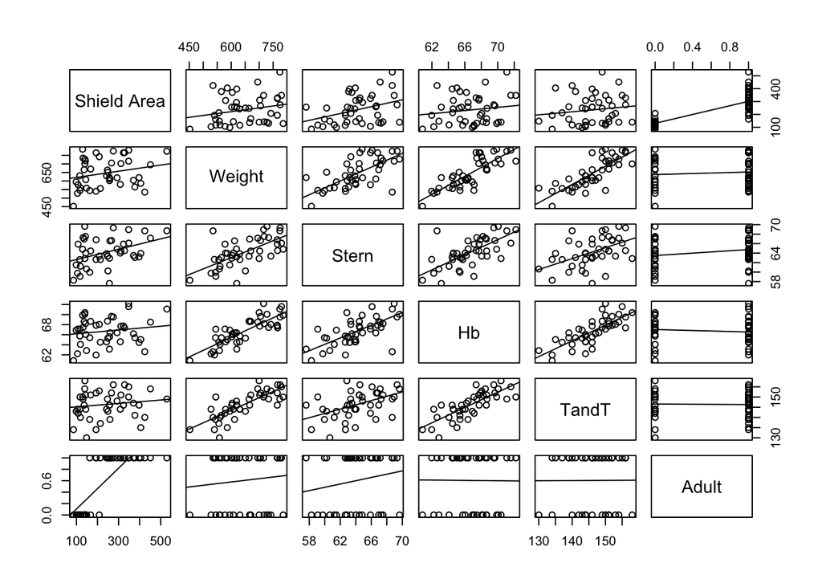

```r
library(MASS)
## Provide a linear fit to the scatterplot
pairs(moorhen,
      panel=function(x,y){points(x,y);abline(rlm(y~x))})
```

- Step 2: covariate space analysis

Given the observed correlation between predictors, we use PCA to explore the effective dimension in predictors.

```r
y = moorhen[,1]
x = moorhen[,-1]
w = sweep(x,2,apply(x,2,mean))
s = prcomp(w %*% diag(1/sqrt(diag(crossprod(w)))))
cumsum(s$sdev^2)/sum(s$sdev^2)
```

```
## [1] 0.6191796 0.8267471 0.9314980 0.9670436 1.0000000
```

We can see that the first 3 principal components captured 93.1% of variance in the predictors. This implies that there are quite strong correlation between predictors and our effective dimension is only around 3.

- Step 3: tentative model fit

We now turn to a model-based apporach. At this stage, we have no specific idea of model form, so we fit a linear model to see there is any problem or a linear model is adequate.

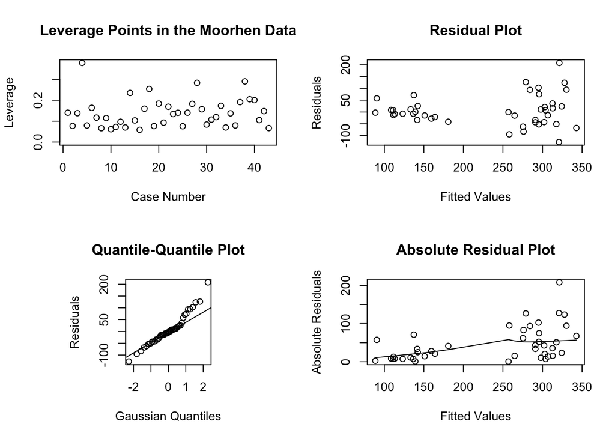

```r
fit = rlm(y~x)
### Model diagnostics
# Leverage plot
par(mfcol=c(2,2),oma = c(0,0,0,0))
plot(1:43,hat(x),ylim=c(0,max(hat(x))),main="Leverage Points in the Moorhen Data", xlab="Case Number",ylab="Leverage")
# Normal Q-Q plot
par(pty="s")
qqnorm(residuals(fit),
       main="Quantile-Quantile Plot",
       xlab="Gaussian Quantiles",
       ylab="Residuals")
qqline(residuals(fit)) # plausibly normal, some heavy tail.
par(pty="m")

# residual vs fitted
plot(fitted(fit),residuals(fit), main="Residual Plot",xlab="Fitted Values",
     ylab="Residuals")

# absolute residuals with loess curve
plot(fitted(fit),abs(residuals(fit)),main="Absolute Residual Plot",
     xlab="Fitted Values", ylab="Absolute Residuals")
lines(lowess(fitted(fit),abs(residuals(fit))))

mtext("Diagnostics for the model fit to the Moorhen data",
      side=3,line=2,outer=T,cex=1.5)
mtext("The model includes all variables on the raw scale",
      side=1,line=2,outer=T)
```

The model residuals show some right skewedness that slightly violates the normality assumption. However, the residuals also show clear heteroscedasticity as the spread of residuals increases as fitted values increases, and the lowess curve for absolute residuals is not flat and shows some increasing trend. This non-constant variance suggests that a log-transformation may be needed to resolve the issue.

We also see clusters in residuals, so we explore it further by colour-coding it with a categorical variable.

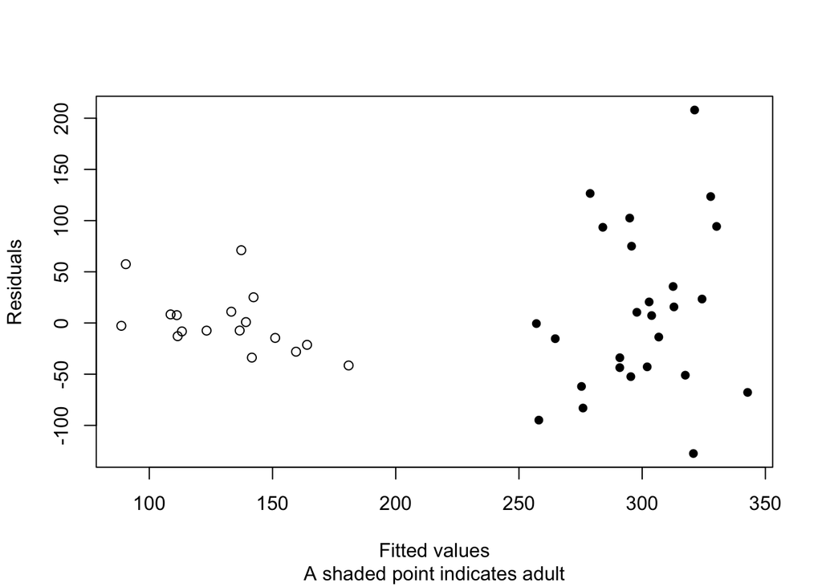

```r
adult=moorhen[,6]
plot(fitted(fit)[adult==0],residuals(fit)[adult==0],pch=1, sub="A shaded point indicates adult",xlab="Fitted values",ylab="Residuals",xlim=range(fitted(fit)),ylim=range(residuals(fit)))
points(fitted(fit)[adult==1],residuals(fit)[adult==1],pch=16)
```

We can clearly see that the right cluster belongs to adult.

- Step 4: after getting info about transformation of response, re-fit the model and do diagnostics

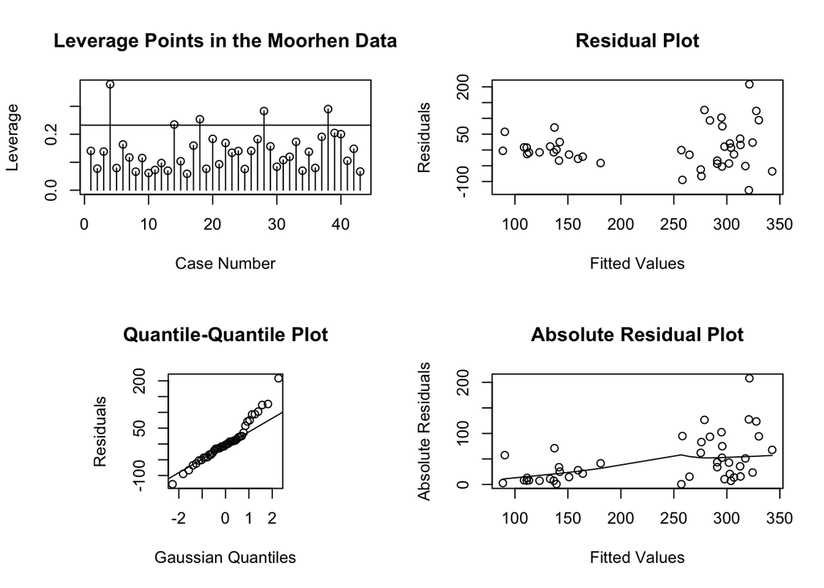

```r
fit2 = rlm(log(y)~x)
par(mfcol=c(2,2))
plot(c(1:43),hat(x),ylim=c(0,max(hat(x))),
     main="Leverage Points in the Moorhen Data",
     xlab="Case Number",
     ylab="Leverage")
segments(c(1:43),0,c(1:43),hat(x))# haven't change, leverage only depends on x
abline(h=10/43) #2p/n

par(pty="s")
qqnorm(residuals(fit),
       main="Quantile-Quantile Plot",
       xlab="Gaussian Quantiles",
       ylab="Residuals")
qqline(residuals(fit))
par(pty="m")

plot(fitted(fit),residuals(fit),
     main="Residual Plot",
     xlab="Fitted Values",
     ylab="Residuals")# change much better, to homoscedasticity

plot(fitted(fit),abs(residuals(fit)),
     main="Absolute Residual Plot",
     xlab="Fitted Values",
     ylab="Absolute Residuals")
lines(lowess(fitted(fit),abs(residuals(fit))))
```

- Step 5: resolve the multicollinearity & model selection

We previously use PCA to find that the predictor space can be represented by a 3-D subspace. So we resort to model selecton algorithms to leave out less important variables.

```r
# best subset selection over all 32 candidate model
regsubsets.out = regsubsets(log(y) ~ x, data=as.data.frame(moorhen), nbest=10,method="exhaustive")
summary(regsubsets.out)
```

```
## Subset selection object
## Call: regsubsets.formula(log(y) ~ x, data = as.data.frame(moorhen),
##     nbest = 10, method = "exhaustive")
## 5 Variables  (and intercept)
##         Forced in Forced out
## xWeight     FALSE      FALSE
## xStern      FALSE      FALSE
## xHb         FALSE      FALSE
## xTandT      FALSE      FALSE
## xAdult      FALSE      FALSE
## 10 subsets of each size up to 5
## Selection Algorithm: exhaustive
##           xWeight xStern xHb xTandT xAdult
## 1  ( 1 )  " "     " "    " " " "    "*"
## 1  ( 2 )  " "     "*"    " " " "    " "
```

[output cut: 29 more lines]

```r
regout=summary(regsubsets.out)
cbind(regout$which,regout$adjr2)
```

```
##   (Intercept) xWeight xStern xHb xTandT xAdult
## 1           1       0      0   0      0      1  0.719276160
## 1           1       0      1   0      0      0  0.123165029
## 1           1       1      0   0      0      0  0.056684177
## 1           1       0      0   1      0      0  0.009467051
## 1           1       0      0   0      1      0  0.006854716
## 2           1       0      1   0      0      1  0.769352752
## 2           1       1      0   0      0      1  0.752789859
## 2           1       0      0   1      0      1  0.749672430
## 2           1       0      0   0      1      1  0.742971481
## 2           1       0      1   1      0      0  0.108284065
## 2           1       1      1   0      0      0  0.104101481
## 2           1       0      1   0      1      0  0.101244516
## 2           1       1      0   1      0      0  0.041622671
## 2           1       1      0   0      1      0  0.039812952
```

[output cut: 17 more lines]

```r
## Visualise the selection result

plt=subsets(regsubsets.out, statistic="adjr2", main = "Adjusted R^2",ylim=c(0.716,0.769),legend=FALSE)
```

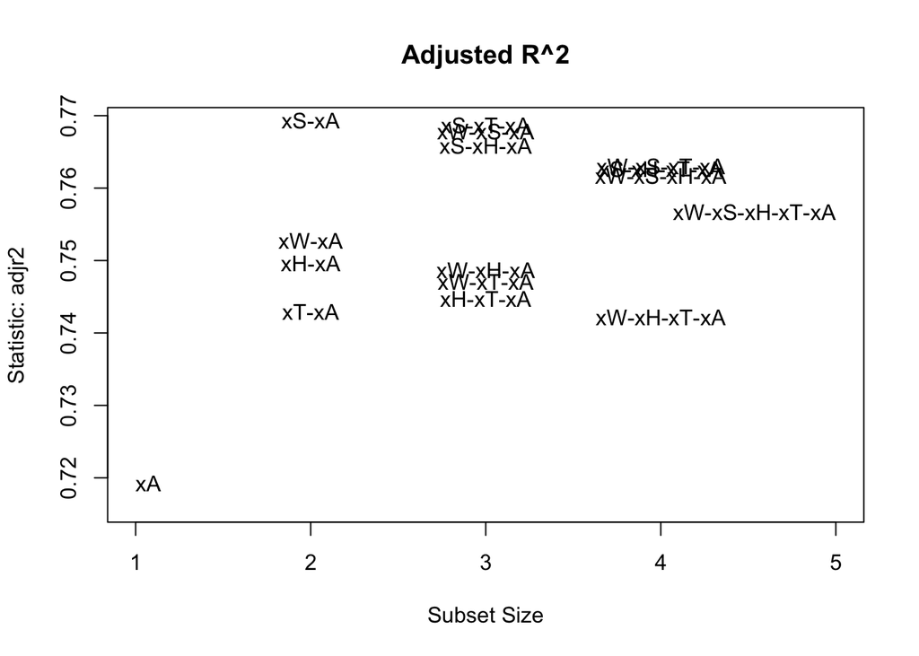

Based on adjusted R^2, the 2-variable model using stern and adult is the best model.

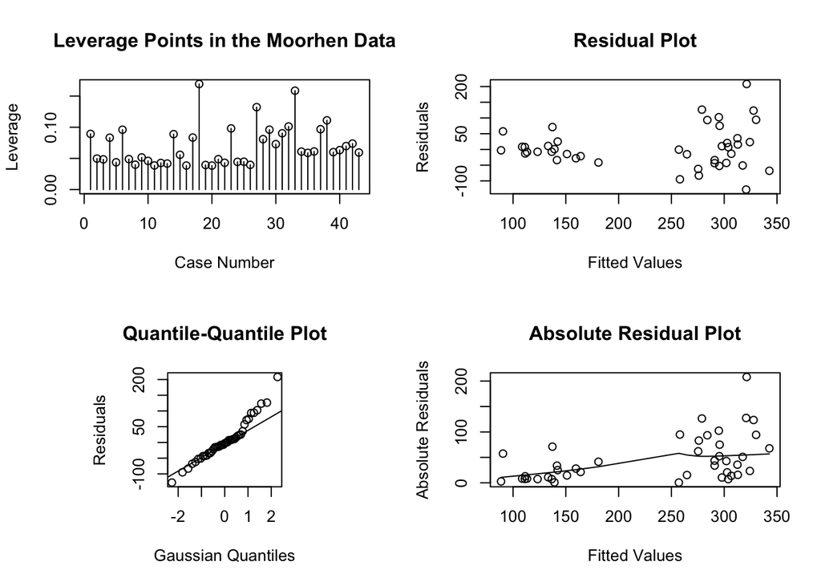

```r
par(mfcol=c(2,2),oma = c(0,0,0,0))

plot(c(1:43),hat(x[,c(2,5)]),ylim=c(0,max(hat(x[,c(2,5)]))),
     main="Leverage Points in the Moorhen Data",
     xlab="Case Number",
     ylab="Leverage")
segments(c(1:43),0,c(1:43),hat(x[,c(2,5)]))
abline(h=10/43) #2p/n

par(pty="s")
qqnorm(residuals(fit),
       main="Quantile-Quantile Plot",
       xlab="Gaussian Quantiles",
       ylab="Residuals")
qqline(residuals(fit))
par(pty="m")

plot(fitted(fit),residuals(fit),
     main="Residual Plot",
     xlab="Fitted Values",
     ylab="Residuals")

plot(fitted(fit),abs(residuals(fit)),
     main="Absolute Residual Plot",
     xlab="Fitted Values",
     ylab="Absolute Residuals")
lines(lowess(fitted(fit),abs(residuals(fit))))

mtext("Diagnostics for the model fit to the Moorhen data",
      side=3,line=2,outer=T,cex=1.5)
mtext("The model includes Stern and Adult with shield area on the log scale",
      side=1,line=2,outer=T)
```

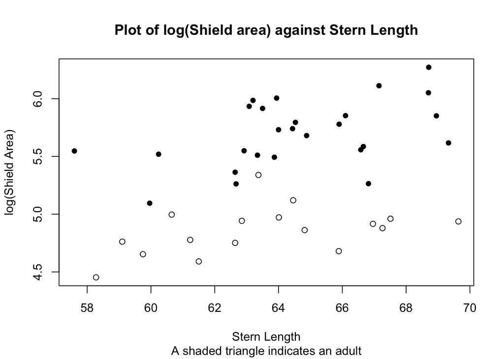

```r
par(mfrow=c(1,1),oma=c(0,0,0,0))
plot(x[,2],log(y),type="n",
     main="Plot of log(Shield area) against Stern Length",
     xlab="Stern Length",
     ylab="log(Shield Area)",
     sub="A shaded triangle indicates an adult")
adult = (x[,5]==1)
points(x[!adult,2],log(y[!adult]),pch=1)
points(x[adult,2],log(y[adult]),pch=16)
abline(fit$coef[1],fit$coef[2]) # adult == 0 or 1
abline(fit$coef[1]+fit$coef[3],fit$coef[2])
```

```r
fit$coefficients
```

```
##   (Intercept)       xWeight        xStern           xHb        xTandT
## -444.52636041   -0.03097264    7.28804590   -2.23331260    1.92779286
##        xAdult
##  160.56481768
```

We need to backtransform, which gives,

Similar multiple regression analysis can follow this combination of visualisation and model-based exploration to refine and diagnose the models.